# Coursera - Reproducible Research - Peer Assessment 1

Wednesday, May 13, 2015

1. Load, read and store the data:

```r
setInternet2(use = TRUE)
dataset_url <- "https://d396qusza40orc.cloudfront.net/repdata%2Fdata%2Factivity.zip"
download.file(dataset_url,"activity.zip")
unzip("activity.zip",exdir = getwd())
results <- read.csv("activity.csv")
```

2. Calculate the total number of steps taken per day and plot a histogram:

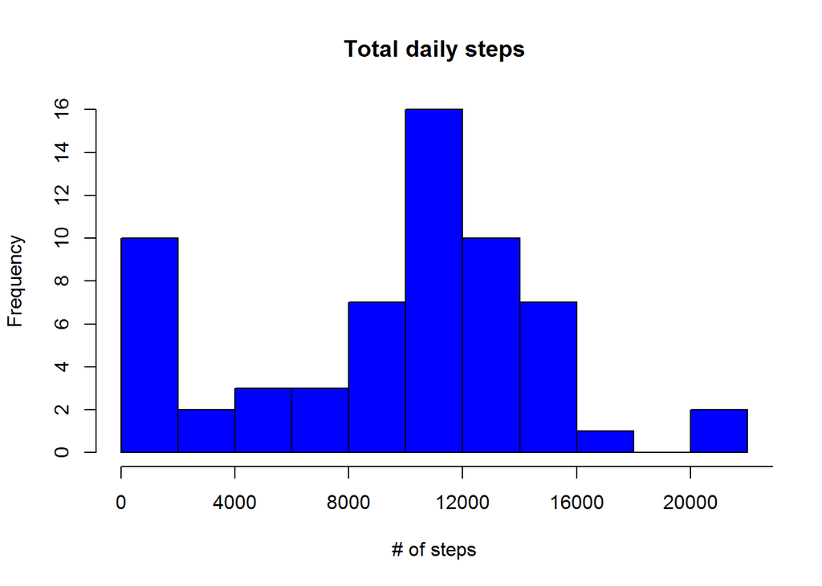

```r
library(dplyr)
groupdata<-group_by(results,date)
daily_steps<-summarize(groupdata,steps=sum(steps, na.rm=TRUE))
hist(daily_steps$steps,col="blue", xlab="# of steps", main="Total daily steps",
           breaks=10, xaxp=c(0,24000,6),yaxp=c(0,16,8))
```

Plot shows a lot of days with <2000 steps (<20 minutes of walking). Either a very sedentary person or a data issue. Lets investigate:

```r
daily_steps$steps
```

```
##  [1]     0   126 11352 12116 13294 15420 11015     0 12811  9900 10304
## [12] 17382 12426 15098 10139 15084 13452 10056 11829 10395  8821 13460
## [23]  8918  8355  2492  6778 10119 11458  5018  9819 15414     0 10600
## [34] 10571     0 10439  8334 12883  3219     0     0 12608 10765  7336
## [45]     0    41  5441 14339 15110  8841  4472 12787 20427 21194 14478
## [56] 11834 11162 13646 10183  7047     0
```

```r
summary(daily_steps)
```

```
##          date        steps
##  2012-10-01: 1   Min.   :    0
##  2012-10-02: 1   1st Qu.: 6778
##  2012-10-03: 1   Median :10395
##  2012-10-04: 1   Mean   : 9354
##  2012-10-05: 1   3rd Qu.:12811
##  2012-10-06: 1   Max.   :21194
##  (Other)   :55
```

```r
summary(daily_steps$steps)
```

```
##    Min. 1st Qu.  Median    Mean 3rd Qu.    Max.
##       0    6778   10400    9354   12810   21190
```

The reason I chose to display results of both `summary(daily_steps)` and `summary(daily_steps$steps)` commands is puzzling errors in the latter - it shows **wrong median value** (10400 instead of 10395) and **wrong maximum value** (21190 instead of 21194) for daily steps. I have no explanation to this. Lesson learned - be careful with `summary()` function.

So correct (or so we think until we get to part 4) mean daily number of steps is 9354 and median is 10395. Quite a few zeros show up in `daily_steps$steps`. To be explained in part 4.

3. Let’s look at average daily activity pattern:

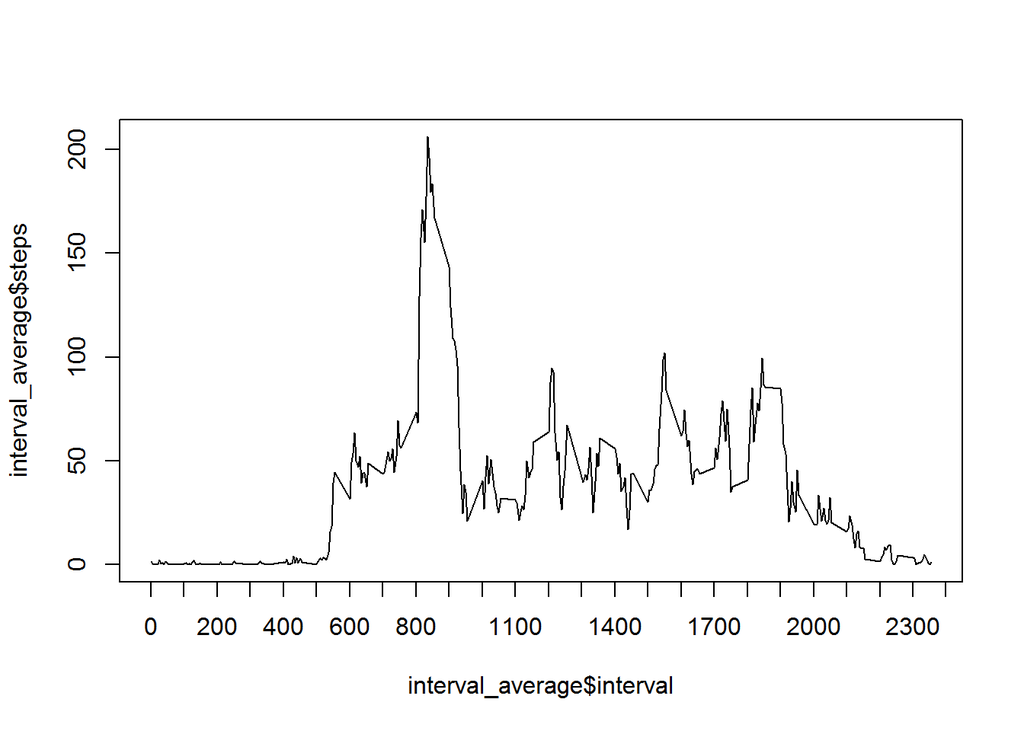

```r
library(dplyr)
groupdata<-group_by(results,interval)
interval_average<-summarize(groupdata,steps=mean(steps, na.rm=TRUE))
plot(interval_average$interval,interval_average$steps,type="l",xaxp=c(0,2400,24))
```

Looks like a daily morning walk (run would have interval steps in 300-500 range). Let’s zoom in on 8:00-9:00 period (we know that each hour generates 12 data points):

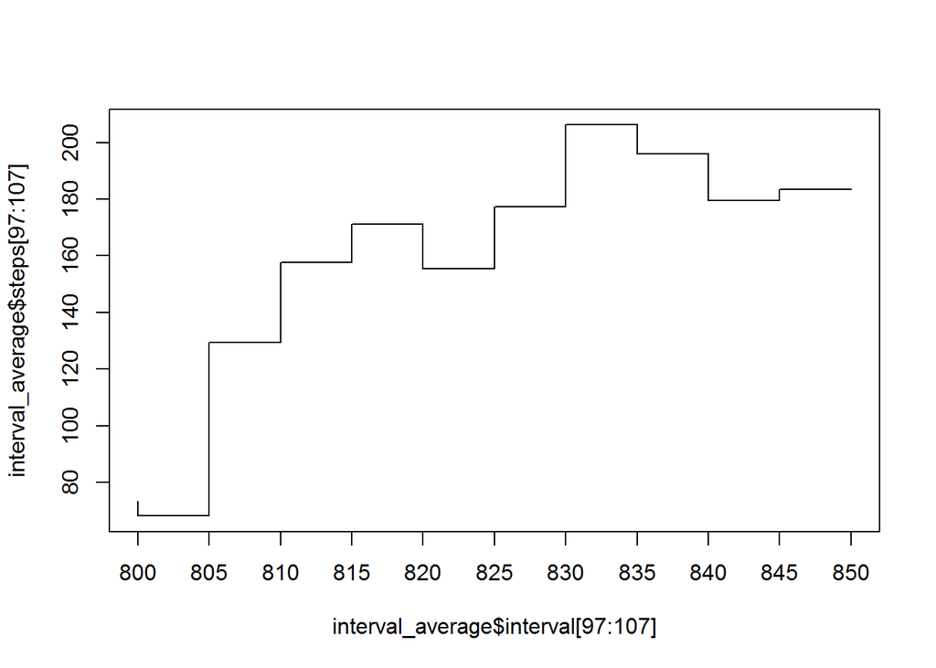

```r
plot(interval_average$interval[97:107],interval_average$steps[97:107],xaxp=c(800,855,11), type="S")
```

And the winner is…

```r
interval_average$steps[interval_average$interval=="835"]
```

```
## [1] 206.1698
```

08:30-08:35 time slot.

As a quick check: `sum(interval_average$steps, na.rm=TRUE)` should be equal to `mean(daily_steps$steps, na.rm=TRUE)`. Averaging by intervals across dates first and then summing should give the same result for average daily steps as summing by intervals for each date first and then averaging across dates.

Alas:

```r
sum(interval_average$steps, na.rm=TRUE)
```

```
## [1] 10766.19
```

```r
mean(daily_steps$steps, na.rm=TRUE)
```

```
## [1] 9354.23
```

Something is clearly wrong. The answer follows in part 4.

4. Now lets deal with those suspicious zeros in daily steps data.

```r
summary(results$steps)
```

```
##    Min. 1st Qu.  Median    Mean 3rd Qu.    Max.    NA's
##    0.00    0.00    0.00   37.38   12.00  806.00    2304
```

```r
emptydata <- results[is.na(results$steps),]
summary(emptydata,maxsum=10)
```

```
##      steps              date        interval
##  Min.   : NA    2012-10-01:288   Min.   :   0.0
##  1st Qu.: NA    2012-10-08:288   1st Qu.: 588.8
##  Median : NA    2012-11-01:288   Median :1177.5
##  Mean   :NaN    2012-11-04:288   Mean   :1177.5
##  3rd Qu.: NA    2012-11-09:288   3rd Qu.:1766.2
##  Max.   : NA    2012-11-10:288   Max.   :2355.0
##  NA's   :2304   2012-11-14:288
##                 2012-11-30:288
##                 2012-10-02:  0
##                 (Other)   :  0
```

So now we have an explanation of that <2000 steps/day spike in the histogram - there are 8 full days of NAs in the data, 2304 in total (those days showed up as zeros in the histogram). Data for the remaining 53 days is complete with no NAs. Lets fill those empty days with average daily interval data stored in `interval_average$steps`

```r
replacement.data <- rep(interval_average$steps,8)
filled.results <- results
filled.results$steps[is.na(results$steps)] <- replacement.data
```

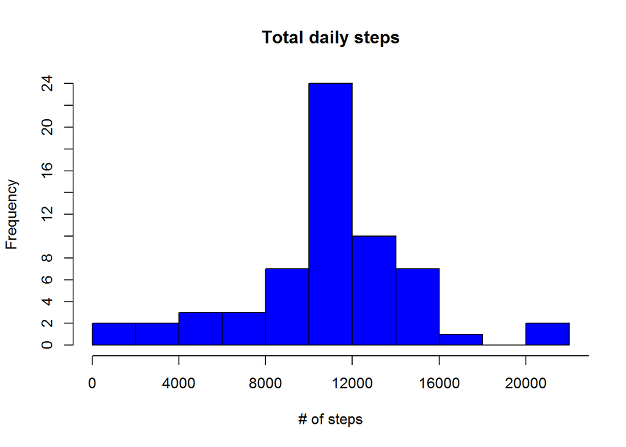

```r
groupdata<-group_by(filled.results,date)
filled_daily_steps<-summarize(groupdata,steps=sum(steps, na.rm=TRUE))
hist(filled_daily_steps$steps,col="blue", xlab="# of steps", main="Total daily steps", breaks=10, xaxp=c(0,24000,6),yaxp=c(0,24,12))
```

Now that we know that 8 full days of data were missing, lets look again at `daily_steps$steps` output in part 2. Those 8 zero entries in `daily_steps$steps` were generated by `daily_steps<-summarize(groupdata,steps=sum(steps, na.rm=TRUE))` command. Somehow, summing up 288 of NAs for those 8 days with missing data in `steps=sum(steps, na.rm=TRUE)` argument in `summarize()` function **yielded zeros instead of NAs**. So when calculating average daily steps from `daily_steps$steps` data, 8 zeros were included in calculation instead of being properly omitted as NAs. Indeed, if one multiplies `mean(daily_steps$steps, na.rm=TRUE)` (=9354) by `61/53` to correct for that issue (53 instead of 61 days should be used in averaging), one recovers correct mean as we calculated via `sum(interval_average$steps, na.rm=TRUE)`: 10766

Issue closed.

Let’s look at weekend effect:

5. Add a weekend flag to `filled.results` and split data into weekend and weekday:

```r
filled.results$weekend <- weekdays(as.Date(filled.results$date)) %in% c("Saturday","Sunday")
weekend_results<-filled.results[filled.results$weekend,]
weekday_results<-filled.results[!filled.results$weekend,]
```

Lets compare intraday plots of average number of steps taken as a function of time interval:

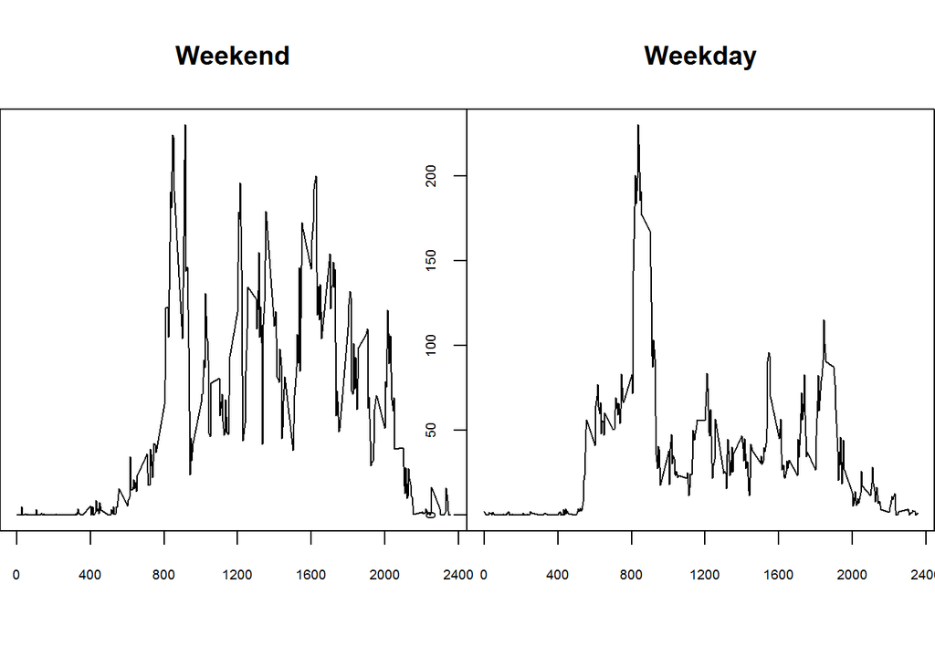

```r
groupdata.weekend<-group_by(weekend_results,interval)
groupdata.weekday<-group_by(weekday_results,interval)
weekend_interval_average<-summarize(groupdata.weekend,steps=mean(steps, na.rm=TRUE))
weekday_interval_average<-summarize(groupdata.weekday,steps=mean(steps, na.rm=TRUE))
mar <- par("mar"); mar[c(2, 4)] <- 0
par(mfrow=c(1,2), mar=mar)
plot(weekend_interval_average$interval,weekend_interval_average$steps,type="l",xaxp=c(0,2400,6), xlab="",main="Weekend",ylab="Weekend # of Steps", cex.axis=0.6)
plot(weekday_interval_average$interval,weekday_interval_average$steps,type="l",xaxp=c(0,2400,6), xlab="",main="Weekday",ylab="Weekday # of Steps", cex.axis=0.6)
```

So looks like there is more running around on weekends during the day, as expected. The person is early raiser on weekends and hits the bed by 10pm - not much difference from weekday schedule. Also, morning walks continue on weekends - so it is perhaps an exercise and not part of a weekday morning commute.